# Lab 1:Intro to R and Data Description

Melissa Pulley

2024-01-26

If you struggle with R today, **Don’t worry** it will get better and easier! Feel free to reach to any of your instructors for help, or meet with us at some point.

My recommendation is: try to work your way through this lab. Work with peers, and you can look for things online, or ask questions. If you are very lost, check the end of this document for help and resources.

## 1 Introduction

Some of you may have heard of R, used R, and are even experts in the R coding language, while others might not even have heard of it. My aim in this class is for you all to be functional, proficient users of R and acquire the skills to (1) perform commonly-used analyses in ecology and related fields and (2) have a good statistical foundation to explore and understand approaches that are less common but may eventually be needed in your work.

Today we will begin with the first task you might be asked to do if you work in a lab as a research assistant or technician: data entry! You might think data entry is easy but it takes some thought as to how you would enter data from a data sheet that came straight from the field/lab into an Excel spreadsheet on your computer.

Hopefully, the short presentation was useful!

## 2 Data entry

Download and open the files, Crab_GTM.jpg, Crab_VCR.jpg, Crab_NIB.jpg, and Crab_PIE.jpg. These files comprise data that researchers have collected by sampling and measuring Atlantic marsh fiddler crabs (*Minuca pugnax*) at four marshes along the US Atlantic coast. The air temperature (from nearby weather stations) and latitude are also recorded on the data sheets.

Enter data of the location, latitude of location, air temperature of location, size (carapace width) of all individual fiddler crabs into an Excel spreadsheet. Think about how you would enter the information and share/discuss your thoughts with your neighbors.

Save the spreadsheet as a .csv file named **FiddlerCrabData.csv** into a new directory named **EEB411_560**.

## 3 Using R

### 3.1 Importing Data

You can import data of various formats into R; they include data tables in the form of .dbf, .csv, and .xlsx files or even spatial data such as vectors (.shp) or rasters (.nc).

But the most common type of data files imported into R are probably .csv files, which you have created in the last section.

You can import the dataset using the function read.csv()

Now, let’s import the dataset!

The way **I** did it, was by typing the following in the **code editor (or source window)**: Do not write code directly in the console!!!!!

```r
read.csv("~/projects/EEB411_560/L2/FiddlerCrabData.csv")
```

but, the way **YOU** will do it, is slightly different. You need to tell R where your file is located. Yours might look something like:

```r
read.csv('C:/Users/mpulley/FiddlerCrabData.csv') # if windows or
read.csv('~/FiddlerCrabData.csv') #if windows saved in "my documents"
```

How do you find the file path? For mac, open Finder, click to the folder where you saved your data, find your file, right-click (or ctrl-click) it, and then click on GetInfo. **I am not a Mac user, so be patient with me**

For windows, find the file on explorer and copy the path.

Once you have identified your path, you can import your file! Hopefully, after you import it, it looks something like this:

```r
getwd()
```

```
## [1] "C:/Users/mpulley/EEB560"
```

```r
read.csv("C:/Users/mpulley/EEB560//FiddlerCrabData.csv")
```

| Site | Latitude | AirTemp | Width |
| --- | --- | --- | --- |
| GTM | 30.0 | 21.742 | 12.43 |
| GTM | 30.0 | 21.742 | 11.84 |
| GTM | 30.0 | 21.742 | 11.58 |
| GTM | 30.0 | 21.742 | 14.44 |
| GTM | 30.0 | 21.742 | 7.55 |
| GTM | 30.0 | 21.742 | 13.10 |
| GTM | 30.0 | 21.742 | 13.00 |
| GTM | 30.0 | 21.742 | 10.32 |
| GTM | 30.0 | 21.742 | 12.68 |
| GTM | 30.0 | 21.742 | 13.56 |

[output cut: 30 more lines]

If it doesn’t, now is the time for you to ask for help (either from the internet, from your peers, a TA or your instructor).

This is also called a data frame in R. Typing the function read.csv() prints out the data frame but it doesn’t store it in a format that can be further manipulated in R. What we want to do is to place this data in an R object. You can place any information (a number, a vector of numbers, a vector of character strings, data frames, matrices, spatial data etc.) in an R object using <-

```r
CrabDat <- read.csv("C:/Users/mpulley/EEB560//FiddlerCrabData.csv")
```

now, there is an object called CrabDat. What happens when you run the following functions?

Answer: It prints the data.

```r
print(CrabDat)
```

And what happens when you run

```r
print(head(CrabDat)) #what is this?
```

What are those functions (print) and (head) doing?

**Answer:** It prints the first 6 rows of data with the data headers.

If you are not sure, try one of my favorite functions in R: the help function!

Run:

```r
?head #?is a great function!
```

And see what it does. You can run that (?) with any function! It is super helpful!

### 3.2 Data exploration

Let’s start with exploring the data! First, let’s look at a summary!

```r
summary(CrabDat)
```

You can also explore the dimensions of the data frame using the function dim(). Try this:

```r
dim(CrabDat)
```

What do you think each number represents?

**Answer:** 40 is the number of rows and 4 is the number of columns.

Why are these numbers important? The number of rows give you information on the sample size, i.e., the total number of observations or “data points”. The number of columns tell you how many variables, i.e, different information, recorded for each observation or data point.

Also try this:

```r
nrow(CrabDat) # what is this? Is the name of the function intuitive?
ncol(CrabDat) # what is this? Is the name of the function intuitive?
```

To see the names of columns, i.e., names of variables recorded, you can do this:

```r
names(CrabDat)
```

names(CrabDat) is a vector. A vector is a one-dimensional series of elements. In this case, you can see four elements – each of them the name of a column in CrabDat. CrabDat has 4 columns/variables so it makes sense to get 4 column/variable names.

To retrieve a specific element of a vector (i.e., xth element), you’d need to add [x] to add the end of names(CrabDat), therefore for the 4th element of names(CrabDat), try:

```r
names(CrabDat)[4] # does it make sense to you?
names(CrabDat) # check the previous answer against this. Makes sense?
```

If you want to rename one column, try

```r
names(CrabDat)[3] = "air_temp"

names(CrabDat)[3]
#previously air_temp in my example
```

The square brackets [] also apply to other types of R objects, such as data frames. Unlike vectors, data frames are two-dimensional: i.e., there are columns as well as rows. Often each row is an observation, while columns describe the different types of data/variables recorded for each observation. The value of a one variable recorded for a given individual is an element.

To retrieve data for a specific row (i.e, the ith row), use [i,] immediately after CrabDat. So if you want to retrieve data for the first row (which is all the information available for observation #1), you can type this:

```r
CrabDat[1,] # note position of i or 1 in this case. It is left of the comma.
```

To retrieve data for a specific column (i.e, the pth column), use [,p] immediately after CrabDat. So if you want to retrieve data for the first column (values of the first variable – site – recorded for all observations), you can type this:

```r
CrabDat[,1] # note position of p or 1 in this case. It is right of the comma.
```

```r
CrabDat[6,3] # row position is left of comma, column pos. is right of comma
```

```r
CrabDat[10,4]
```

```
## [1] 13.56
```

**Answer**: The size of the 10th crab is 13.56 mm.

**Answers:**

```r
CrabDat[2,2] #Latitude of 2nd observation
```

```
## [1] 30
```

```r
CrabDat[3,] #all data from third observation
```

|  | Site | Latitude | AirTemp | Width |
| --- | --- | --- | --- | --- |
| 3 | GTM | 30 | 21.742 | 11.58 |

You can extract multiple columns and rows of CrabDat if you want to. The idea is to concatenate the different numbers referring to the row and column positions you want, using c(). For example:

```r
c(1,2,4) # this prints 1, 2, and 4
```

```
## [1] 1 2 4
```

Look (and run, the following three code chunks)

```r
CrabDat[c(1,2,4), 3] # note that c(1,2,4) is left of the comma
```

**Answer**: This code extract the 1st, 2nd, and 4th rows (observations) of the 3 column, AirTemp

```r
CrabDat[1:5, 3]
```

**Answer**: This code extracts the air temperature (column 3) from observations (rows) 1 through 5.

```r
1:5
```

**Answer**: This code gives integers between 1 and 5.

See above.

Another way of retrieving data for a specific column or variable is to use $VarName immediately after CrabDat, where VarName is the name of the column/variable. So to retrieve measurements of size for all fiddler crab individuals in the data set, you can type:

```r
CrabDat$Width # since ‘size’ is the name of the variable you want
```

You can also do this to get the same information as above (size of first five individuals):

```r
CrabDat$Width[1:5]
```

**Answer**: Because “CrabDat$Width” is only one column, it is not necessary to index by row and column, instead, we can extract by the index (or row) without needing to reference a column.

```r
CrabDat$AirTemp[1:10]
```

```
##  [1] 21.742 21.742 21.742 21.742 21.742 21.742 21.742 21.742 21.742 21.742
```

**Answer**: Yes, because all of the first 10 individuals were observed at the same site.

### 3.3 Beginning to describe and visualize data

Obviously, we are just scratching the surface of data processing in the previous section. These are the basic building blocks, which I hope will help you learn different ways of processing data in R in the future. We will come back to this in future tutorials and you’d realize that there is often many ways of doing the same thing in R.

Now let’s move on to simple data description and visualization. We will briefly cover some of these topics in the future, but I want you all to get an intuition by doing first.

### 3.4 Types of data

There are two main data/variable types: (1) categorical or qualitative data; and (2) numerical or quantitative data.

In CrabDat, which variables (columns) are categorical and which ones are numeric?

```r
summary(CrabDat)
```

```
##      Site              Latitude        AirTemp          Width
##  Length:40          Min.   :30.00   Min.   :10.29   Min.   : 7.55
##  Class :character   1st Qu.:32.48   1st Qu.:13.79   1st Qu.:12.88
##  Mode  :character   Median :35.25   Median :16.96   Median :14.61
##                     Mean   :35.80   Mean   :16.49   Mean   :15.18
##                     3rd Qu.:38.58   3rd Qu.:19.66   3rd Qu.:18.68
##                     Max.   :42.70   Max.   :21.74   Max.   :21.19
```

If a variable has information like mean, median, or max, it is numerical/quantitative data. The variable site is shown as a character variable. This is an example of categorical or qualitative data. It makes sense, as each code refers to a given site where crabs were sampled.

You can formally define site as a categorical (factor) variable using as.factor

```r
CrabDat$Site <- as.factor(CrabDat$Site)
```

Now run a summary()of CrabDat again. What does it say under site now?

```r
summary(CrabDat) # is there more information now? Yes
```

```
##   Site       Latitude        AirTemp          Width
##  GTM:10   Min.   :30.00   Min.   :10.29   Min.   : 7.55
##  NIB:10   1st Qu.:32.48   1st Qu.:13.79   1st Qu.:12.88
##  PIE:10   Median :35.25   Median :16.96   Median :14.61
##  VCR:10   Mean   :35.80   Mean   :16.49   Mean   :15.18
##           3rd Qu.:38.58   3rd Qu.:19.66   3rd Qu.:18.68
##           Max.   :42.70   Max.   :21.74   Max.   :21.19
```

See the new information!

### 3.5. Describing and visualizing different types of data

Categorical/qualitative data are data that do not have magnitude that can be measured by numbers (i.e., not quantitative). Categorical data include assignments of samples/individuals/observations into groups or categories. For example, the type of high-schools in the US can be classified into public vs. private high schools. There are two discrete categories: public or private. Therefore this is a categorical variable.

In CrabDat, site is categorical. We can summarize categorical variables by using table()

```r
table(CrabDat$Site)
```

```
##
## GTM NIB PIE VCR
##  10  10  10  10
```

The printed output counts the number of observations belonging to each category of the site variable.

Numeric/quantitative data are data that have magnitude and they can be described numerically. Larger values of a given quantitative variable have a larger magnitude than smaller values of the same variable. For example, the mean ACT score of seniors in a given high school is a numeric/quantitative variable.

In CrabDat, size, air_temp, and latitude are numeric/quantitative variables.

For quantitative variables, we can plot a histogram to visualize the distribution (or spread) of values. In R, we can use hist()

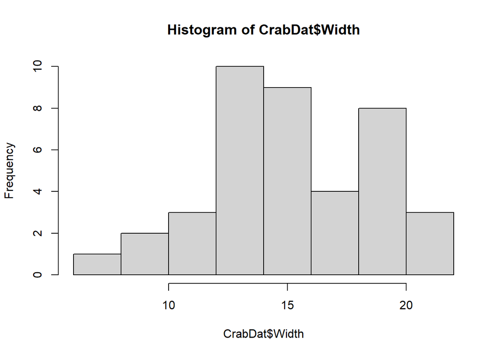

```r
hist(CrabDat$Width) # what do you think of the distribution
```

We can use breaks=n to change the number of breaks. Look at:

```r
?hist
```

and then run:

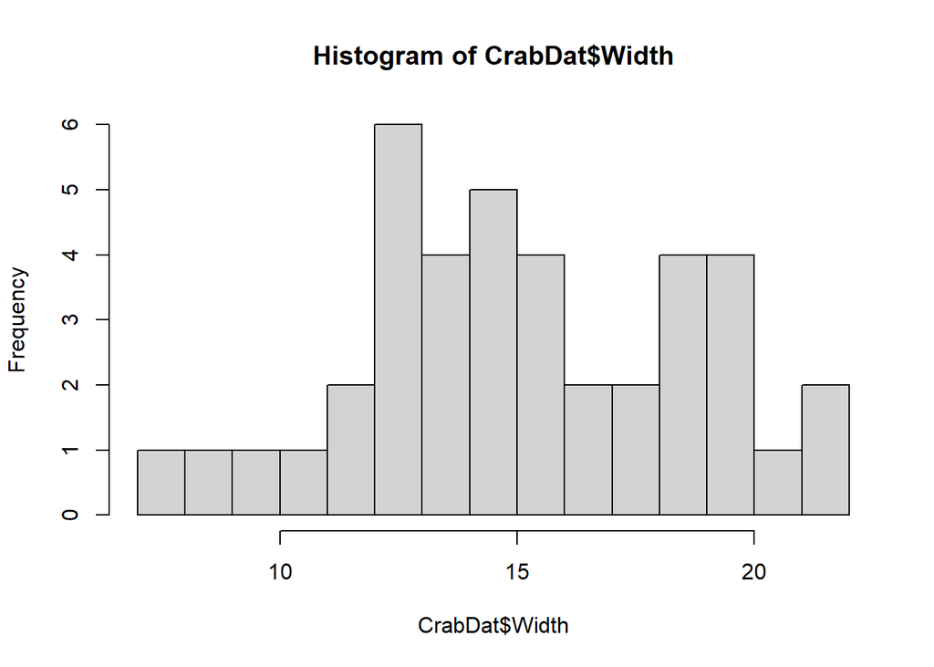

```r
hist(CrabDat$Width, breaks=10) # what do you think of the distribution
```

But replace x for an appropriate number.

**Answer**: I chose 10 breaks because I wanted to have a finer partition of the data so that I can see more detail at the center of the data.

You can also use boxplots to visualize the spread of a given across different categories of another categorical variables. Here, we want to visualize the distribution of individual crab sizes across different sites using boxplot().

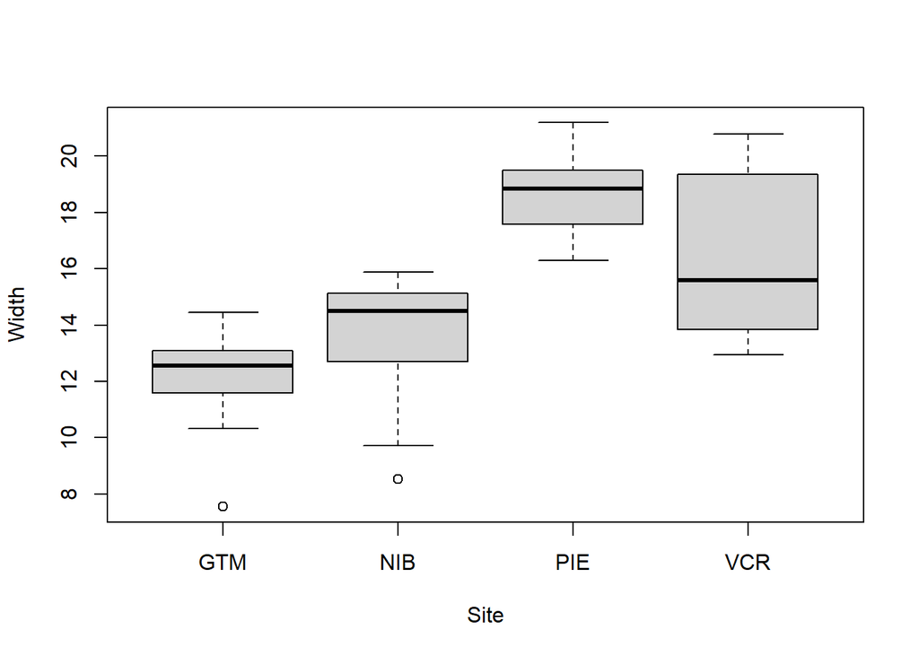

```r
boxplot(Width~Site, data=CrabDat) # what do you think?
```

**Answer:** For one site, the dark line indicates the median width for that site. The box starts from the first quartile and extends to the third quartile to indicate the spread of the central data points. The thin lines indicate the min and max data points, with the exception of outliers, indicated by circles.

Last, for this tutorial, sometimes we want to visualize the relationship between two quantitative variables. The quickest way to do this is to make a dot plot (scatterplot) using plot()

```r
#plot(size~latitude, data=CrabDat) # what do you think?
```

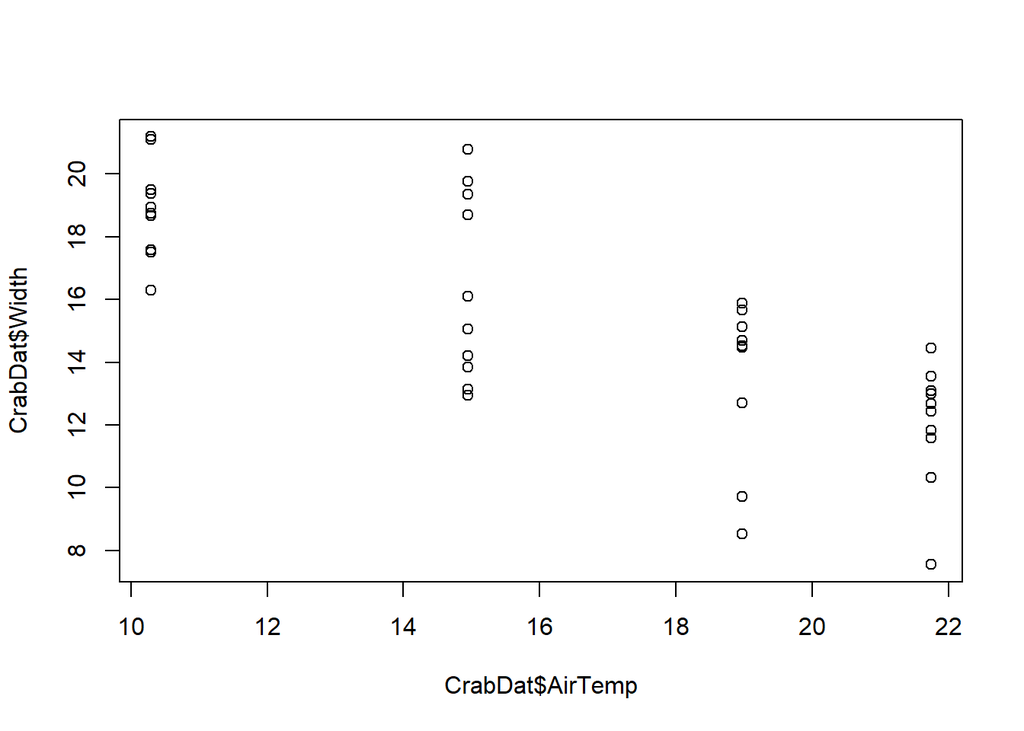

```r
plot(CrabDat$AirTemp,CrabDat$Width)
```

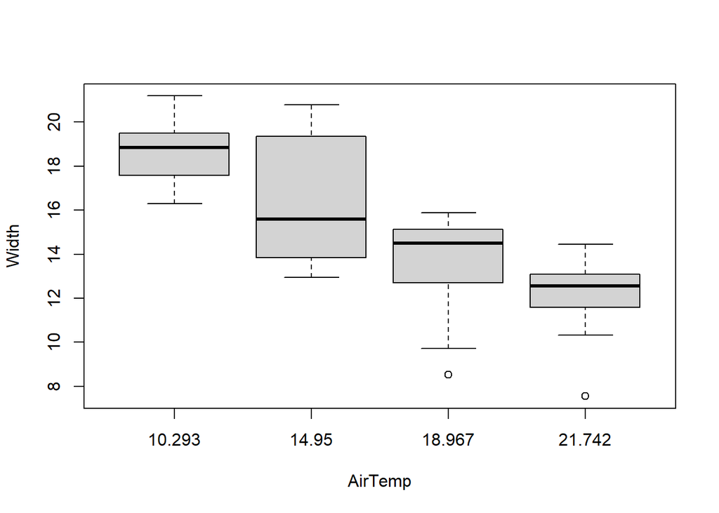

```r
boxplot(Width~AirTemp, data=CrabDat)
```

**Answer** While I examined both a dot plot and a box plot, because there are only four possible temperatures, the box plot is more descriptive because it visualizes summary of the data distribution so that you can see median, quartiles etc for each location, identified by air temperature.

## 4 Extra resources, Extra credits, and other information

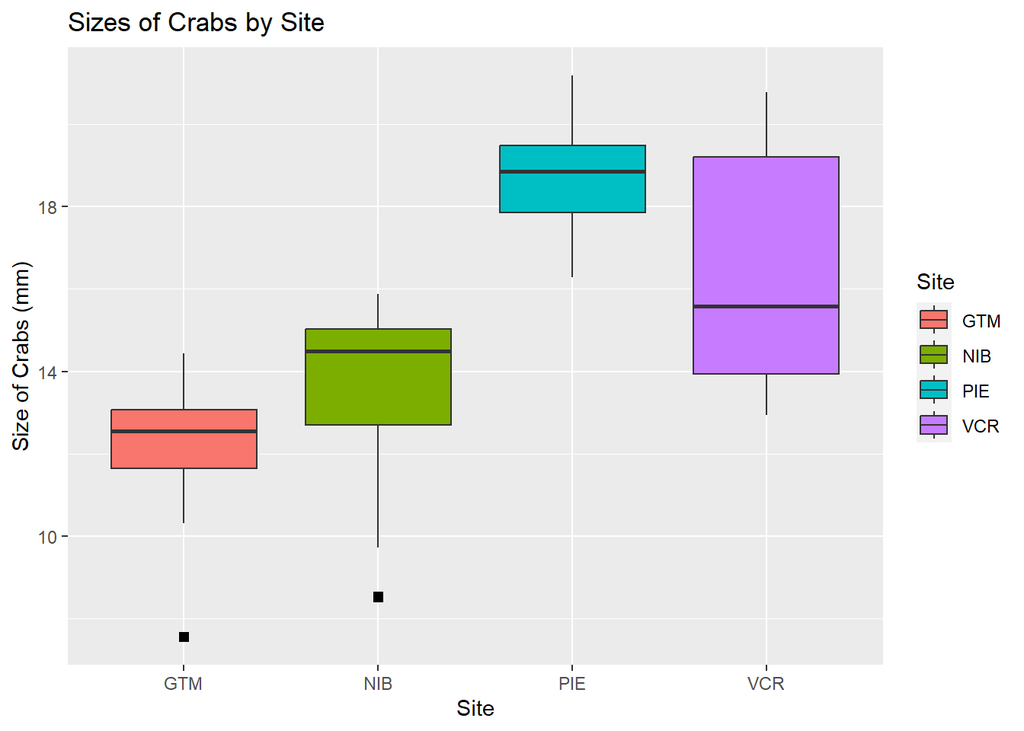

```r
library(ggplot2)
ggplot(data=CrabDat, aes(x=Site,y=Width, fill=Site)) +
  geom_boxplot(outlier.colour="black", outlier.shape=15,
             outlier.size=2, notch=FALSE) +
    labs(title = "Sizes of Crabs by Site") +
        ylab("Size of Crabs (mm)") + xlab("Site")
```

*Resources*